# Practical Machine Learning

Max Moro

August 22, 2015

## Background

Using devices such as Jawbone Up, Nike FuelBand, and Fitbit it is now possible to collect a large amount of data about personal activity relatively inexpensively. These type of devices are part of the quantified self movement – a group of enthusiasts who take measurements about themselves regularly to improve their health, to find patterns in their behavior, or because they are tech geeks. One thing that people regularly do is quantify how much of a particular activity they do, but they rarely quantify how well they do it. In this project, your goal will be to use data from accelerometers on the belt, forearm, arm, and dumbbell of 6 participants. They were asked to perform barbell lifts correctly and incorrectly in 5 different ways. More information is available from the website here: http://groupware.les.inf.puc-rio.br/har (see the section on the Weight Lifting Exercise Dataset).

## Data

The training data for this project are available here:

https://d396qusza40orc.cloudfront.net/predmachlearn/pml-training.csv

The test data are available here:

https://d396qusza40orc.cloudfront.net/predmachlearn/pml-testing.csv

The data for this project come from this source: http://groupware.les.inf.puc-rio.br/har. If you use the document you create for this class for any purpose please cite them as they have been very generous in allowing their data to be used for this kind of assignment.

## Objective

The goal of the project is to predict the manner in which they did the exercise. This is the “classe” variable in the training set.

This report describes how the model is build, its cross validation, and the expected out of sample error.

## Loading Data set

```r
library(caret)
```

```r
library(ggplot2)
library(data.table)
library(rpart)
library(randomForest)
library(e1071)
library(doParallel)
train <- data.table(read.csv('pml-training.csv'))
test <- data.table(read.csv('pml-testing.csv'))
```

Dimensions of the train and test set

```r
dim(train)
```

```
## [1] 19622   160
```

```r
dim(test)
```

```
## [1]  20 160
```

## Data Cleaning

Excluding the columns that don’t contain useful info

```r
cols = names(train)[which(!names(train) %in% c('X','user_name','raw_timestamp_part_1','raw_timestamp_part_2','cvtd_timestamp','new_window','num_window'))]
train.good=train[,.SD,.SDcols=cols]
```

Excluding the columns that have NA or BLANK value

```r
train.good=train.good[,.SD,.SDcols=which(colSums(is.na(train.good)) == 0)]
train.good=train.good[,.SD,.SDcols=which(colSums(train.good == '') == 0)]
```

Dimensions of the train set after cleaning

```r
dim(train.good)
```

```
## [1] 19622    53
```

## Partitioning Data

Partitioning the Train data with 80% of data for training the model

```r
part = createDataPartition(y=train.good$classe, p=0.80, list=TRUE)
train.train = train.good[part$Resample1]
train.test = train.good[-part$Resample1]
```

## Data Analysis

Distribution of rows per eahc level

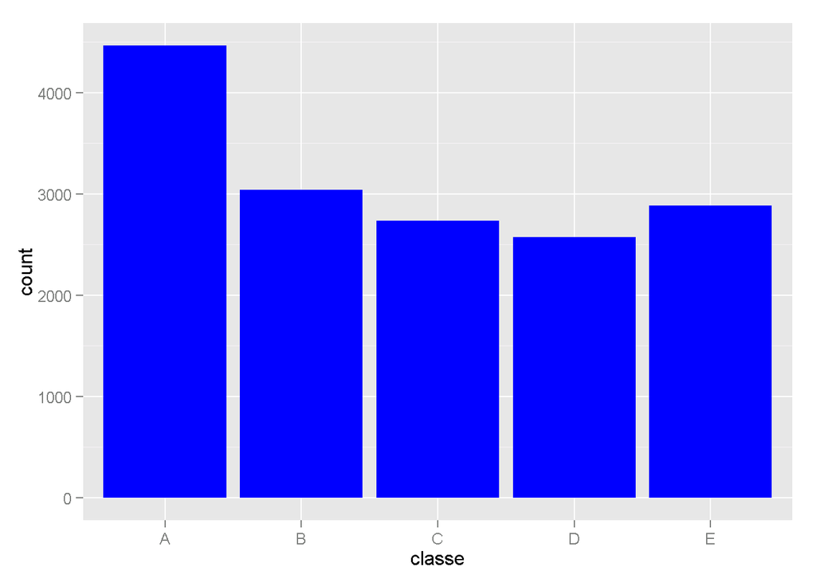

```r
ggplot(data=train.train, aes(x=classe))+
    geom_bar(fill='blue')
```

## Training Models

```r
registerDoParallel(cores=8)
model.rf = train(classe~.,data=copy(train.train),method='rf')
model.tree = train(classe~.,data=copy(train.train),method='rpart')
```

## Prediction with the Models

```r
predict.rf = predict(model.rf, train.test)
predict.tree = predict(model.tree, train.test)
```

## Consution Matrices

### Using Random Forest

```r
confusionMatrix(predict.rf, train.test$classe)
```

```
## Confusion Matrix and Statistics
##
##           Reference
## Prediction    A    B    C    D    E
##          A 1114    5    0    0    0
##          B    1  750    2    0    0
##          C    0    3  679    9    0
##          D    0    1    3  634    2
##          E    1    0    0    0  719
##
## Overall Statistics
##
##                Accuracy : 0.9931
##                  95% CI : (0.99, 0.9955)
##     No Information Rate : 0.2845
##     P-Value [Acc > NIR] : < 2.2e-16
##
##                   Kappa : 0.9913
##  Mcnemar's Test P-Value : NA
##
## Statistics by Class:
##
##                      Class: A Class: B Class: C Class: D Class: E
## Sensitivity            0.9982   0.9881   0.9927   0.9860   0.9972
## Specificity            0.9982   0.9991   0.9963   0.9982   0.9997
## Pos Pred Value         0.9955   0.9960   0.9826   0.9906   0.9986
## Neg Pred Value         0.9993   0.9972   0.9985   0.9973   0.9994
## Prevalence             0.2845   0.1935   0.1744   0.1639   0.1838
## Detection Rate         0.2840   0.1912   0.1731   0.1616   0.1833
## Detection Prevalence   0.2852   0.1919   0.1761   0.1631   0.1835
## Balanced Accuracy      0.9982   0.9936   0.9945   0.9921   0.9985
```

### Using Tree

```r
confusionMatrix(predict.tree, train.test$classe)
```

```
## Confusion Matrix and Statistics
##
##           Reference
## Prediction    A    B    C    D    E
##          A 1000  330  294  295  103
##          B   21  248   26  105  109
##          C   91  181  364  243  193
##          D    0    0    0    0    0
##          E    4    0    0    0  316
##
## Overall Statistics
##
##                Accuracy : 0.4915
##                  95% CI : (0.4757, 0.5072)
##     No Information Rate : 0.2845
##     P-Value [Acc > NIR] : < 2.2e-16
##
##                   Kappa : 0.3358
##  Mcnemar's Test P-Value : NA
##
## Statistics by Class:
##
##                      Class: A Class: B Class: C Class: D Class: E
## Sensitivity            0.8961  0.32675  0.53216   0.0000  0.43828
## Specificity            0.6359  0.91751  0.78141   1.0000  0.99875
## Pos Pred Value         0.4946  0.48723  0.33955      NaN  0.98750
## Neg Pred Value         0.9390  0.85032  0.88776   0.8361  0.88759
## Prevalence             0.2845  0.19347  0.17436   0.1639  0.18379
## Detection Rate         0.2549  0.06322  0.09279   0.0000  0.08055
## Detection Prevalence   0.5154  0.12975  0.27326   0.0000  0.08157
## Balanced Accuracy      0.7660  0.62213  0.65679   0.5000  0.71852
```

The Random Forest model has a better accuracy on the validation set.

The prediction on the test set will be made using the Random Forest model

I'm expecting an output from the Random Forest prediction model that is 0.99 accurate within a 0.95% of conifdence interval.

## Prediction on 20 records

```r
test.pred <- predict(model.rf, test, type = "raw")
test.pred
```

```
##  [1] B A B A A E D B A A B C B A E E A B B B
## Levels: A B C D E
```